# Chapter 8 — Sea Ice Image Processing Applications

## Appendix B — the `IceImage` data structure (pp. 221–225)

"The processed results are stored as a MATLAB data structure … presented in Appendix B" (p. 184). The appendix's Figs. B.1–B.3 are IDE screenshots of exactly this structure, and `SeaIce_Image_Structure.m` is what builds it. It landed in Chapter 8 because Chapter 8 is the first chapter that *consumes* it. Four blocks:

- **`Param`** (17 fields) — everything known at capture time: `NumPix_x`/`NumPix_y`, `TiltAngle`, `PanAngle`, `Location`, `Creator`, and eleven fields the script leaves empty.
- **`Field`** (15 fields) — the ice field as a whole: physical lengths and pixel scales, `NumFloes`/`NumBrash`, the four coverages plus `CovOther` (the residue between connected floes, never printed in the book), and the **`FSD`** cell array of `[int_min, int_max, num]` triplets.
- **`Floe(i)`** — `Center`, `Area` (in pixels), `Perimeter`, the `Polygon` sub-structure (`Vertices`, `Center`, `Area`, `Perimeter`, `Intersect`) and `Pixels`.
- **`Brash(i)`** — `Center`, `Area`, the `Circle` sub-structure (`Radius`, `Perimeter`, `Intersect`), `Pixels`.

The rings stored in `Polygon.Vertices` are **open**: lines 15–16 of the M-file delete the duplicated closing vertex, because "there shall be no duplicated vertices" (p. 222). `core.icestruct` mirrors all of this as dataclasses plus `.mat` I/O, and is `exact` against the shipped structure: all 12 numeric `Field` members, all 51 `FSD` triplets, every open ring including vertex order, and all **3992** overlap-list entries.

One field-level contradiction worth recording: the script hard-codes `Location = 'Ny-Alesund'`, `Creator = 'UAV'`, `LengthSI_x = 50`, `LengthSI_y = 18` — the §8.2 UAV field — while the shipped `.mat` holds `Creator = 'Helicopter'`, `PrjName = 'OATRC 2015'` and empty lengths. The `.mat` was produced by a **§8.3 variant** of the §8.2 script (erratum **E7**), so the port makes them arguments with the script's values as defaults.

```python
print(f"Param : NumPix_x = {ICE.Param.NumPix_x}, NumPix_y = {ICE.Param.NumPix_y}, "
      f"TiltAngle = {ICE.Param.TiltAngle}, PanAngle = {ICE.Param.PanAngle}, "
      f"Location = {ICE.Param.Location!r}, Creator = {ICE.Param.Creator!r}, PrjName = {ICE.Param.PrjName!r}")
print(f"Field : LengthSI = {ICE.Field.LengthSI_x} x {ICE.Field.LengthSI_y} m, PixScale = "
      f"{ICE.Field.PixScale_x} x {ICE.Field.PixScale_y} m/px, CovOther = {ICE.Field.CovOther:.10f}")
f0 = ICE.Floe[0]
print(f"Floe(1): Center = {np.round(np.atleast_1d(f0.Center).ravel(), 4).tolist()}, Area = {f0.Area} px, "
      f"Perimeter = {float(np.atleast_1d(f0.Perimeter)[0]):.4f}")
print(f"         Polygon: {f0.Polygon.Vertices.shape[0]} vertices (OPEN ring: first {np.round(f0.Polygon.Vertices[0], 1).tolist()}"
      f" != last {np.round(f0.Polygon.Vertices[-1], 1).tolist()}), Area = {f0.Polygon.Area:.4f}, "
      f"Intersect.floe = {np.atleast_1d(f0.Polygon.Intersect.floe).tolist()[:8]}")
b0 = ICE.Brash[0]
print(f"Brash(1): Center = {np.round(np.atleast_1d(b0.Center).ravel(), 4).tolist()}, Area = {b0.Area} px, "
      f"Circle.Radius = {b0.Circle.Radius:.6f}, Circle.Perimeter = {b0.Circle.Perimeter:.6f} (= 2*pi*r, "
      "recomputed here rather than copied from brash(i).Perimeter)")

G = overlap_graph(ICE)
print(f"\noverlap lists: floe-floe {G['n_floe_floe']}, floe-brash {G['n_floe_brash']}, "
      f"brash-brash {G['n_brash_brash']}, brash-floe {G['n_brash_floe']} entries"
      + mcd_book("1106 / 1171 / 1171 / 544 on the shipped structure — all reproduced"))
print(f"  consistency: floe-floe symmetric {G['floe_floe_symmetric']}, brash-brash symmetric "
      f"{G['brash_brash_symmetric']}, floe-brash consistent with brash-floe {G['floe_brash_consistent']}")

# .mat round-trip: save_iceimage_mat / load_iceimage_mat are the Appendix-B I/O pair.
import tempfile
tmp = Path(tempfile.gettempdir()) / "ch08_iceimage_roundtrip.mat"
save_iceimage_mat(tmp, ICE)
BACK = load_iceimage_mat(tmp)
print(f"\n.mat round-trip through save_iceimage_mat/load_iceimage_mat: {BACK.summary()}; "
      f"Floe(1).Polygon.Area identical: {BACK.Floe[0].Polygon.Area == ICE.Floe[0].Polygon.Area}")
```

```
Param : NumPix_x = 394, NumPix_y = 1038, TiltAngle = 90, PanAngle = 0, Location = 'Ny-Alesund', Creator = 'UAV', PrjName = None
Field : LengthSI = 50 x 18 m, PixScale = 0.12690355329949238 x 0.017341040462427744 m/px, CovOther = 0.0373448549
Floe(1): Center = [388.9773, 550.4545], Area = 44 px, Perimeter = 25.4140
         Polygon: 5 vertices (OPEN ring: first [385.0, 552.0] != last [394.0, 552.0]), Area = 30.5000, Intersect.floe = []
Brash(1): Center = [109.0, 18.0], Area = 5 px, Circle.Radius = 1.261566, Circle.Perimeter = 7.926655 (= 2*pi*r, recomputed here rather than copied from brash(i).Perimeter)

overlap lists: floe-floe 156, floe-brash 112, brash-brash 34, brash-floe 112 entries
  consistency: floe-floe symmetric True, brash-brash symmetric True, floe-brash consistent with brash-floe True
```

```
.mat round-trip through save_iceimage_mat/load_iceimage_mat: IceImage: 394x1038 px, 196 floes, 329 brash pieces, FSD 51 intervals; Floe(1).Polygon.Area identical: True
```

```
Field.FSD: 51 triplets, first three [[43, 143, 44], [144, 244, 47], [245, 345, 13]], counts sum to 196 = NumFloes (196)

re-counting the floe areas from the PRINTED interval labels [int_min, int_max]:
  first interval 43..143 -> 72 floes, but the stored count is 44
  28 of the 51 intervals disagree with their own labels
  the true first bin is everything <= 93.5 (the midpoint of the first two centres), and it is unbounded below
VERDICT (erratum E8): the shipped LABELS are wrong, the shipped COUNTS are right. Reproducing the counts requires MATLAB's hist() semantics (core.histogram.hist, bin centres), not the labels — which is exactly how the port reproduces all 51 shipped triplets at 0.
  hist() with those centres reproduces the stored counts: True
```

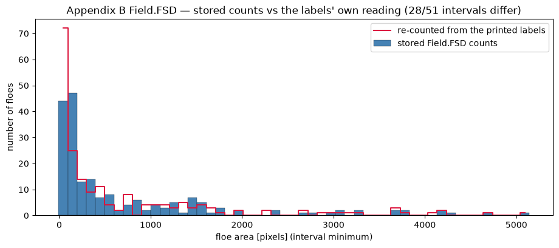

```python
# The FSD block, and the trap in it (erratum E8).  `SeaIce_Image_Structure.m` line 98 is
#     inter = fix((max_x - min_x)/nbins);  [z, n] = hist(floe_area, min_x:inter:max_x);
# so `n` are bin CENTRES; the true edges are their midpoints and both outer bins are UNBOUNDED.  Lines 100-101
# then label the triplets [int_min, int_max] = [n, [n(2:end)-1, max_x]] — labels that describe a DIFFERENT rule.
fsd = np.array(ICE.Field.FSD)
print(f"Field.FSD: {len(fsd)} triplets, first three {fsd[:3].tolist()}, counts sum to {int(fsd[:, 2].sum())} "
      f"= NumFloes ({ICE.Field.NumFloes})")

recount = np.array([int(((areas_px >= lo) & (areas_px <= hi)).sum()) for lo, hi, _ in fsd])
bad = int((recount != fsd[:, 2]).sum())
print(f"\nre-counting the floe areas from the PRINTED interval labels [int_min, int_max]:")
print(f"  first interval {fsd[0, 0]}..{fsd[0, 1]} -> {recount[0]} floes, but the stored count is {fsd[0, 2]}")
print(f"  {bad} of the {len(fsd)} intervals disagree with their own labels")
print(f"  the true first bin is everything <= {(fsd[0, 0] + fsd[1, 0]) / 2:.1f} (the midpoint of the first two "
      "centres), and it is unbounded below")
print("VERDICT (erratum E8): the shipped LABELS are wrong, the shipped COUNTS are right. Reproducing the counts "
      "requires MATLAB's hist() semantics (core.histogram.hist, bin centres), not the labels — which is exactly "
      "how the port reproduces all 51 shipped triplets at 0.")

z_hist, n_hist = matlab_hist(areas_px, matlab_colon(float(areas_px.min()),
                                                    float(np.trunc((areas_px.max() - areas_px.min()) / 50)),
                                                    float(areas_px.max())))
print(f"  hist() with those centres reproduces the stored counts: {np.array_equal(z_hist, fsd[:, 2])}")

fig, ax = plt.subplots(figsize=(11, 4.2))
ax.bar(fsd[:, 0], fsd[:, 2], width=max(int(fsd[1, 0] - fsd[0, 0]), 1), color="steelblue", edgecolor="k",
       linewidth=0.2, label="stored Field.FSD counts")
ax.step(fsd[:, 0], recount, where="mid", color="crimson", linewidth=1.4,
        label="re-counted from the printed labels")
ax.set_xlabel("floe area [pixels] (interval minimum)"); ax.set_ylabel("number of floes"); ax.legend()
ax.set_title(f"Appendix B Field.FSD — stored counts vs the labels' own reading ({bad}/{len(fsd)} intervals differ)")
plt.show()
```

## The MATLAB traps this chapter turns up

Chapter 8's code is short, but it contains more "reads one way, runs another" constructs than any earlier chapter. Each of these was confirmed by running the original file in MATLAB R2025a, and each is **reproduced faithfully** rather than corrected — a port whose output differs from the authors' is not a better port.

| # | what the code says | what MATLAB actually does | consequence |
| --- | --- | --- | --- |
| **E9** | `[xx,yy] = polyxpoly(...); if xx ~= NaN` | `x ~= NaN` is `true` for *every* element (even for `NaN` itself), so the `if` reduces to **`if ~isempty(xx)`** | overlap means the boundaries **cross**; a floe entirely **inside** another is reported as *not* overlapping |
| **E10** | `t = 0:0.05:6.28` — "a circle" | **126** samples ending at **6.25 rad**, because 6.28 is not a multiple of 0.05 (and 6.28 < 2π anyway) | every brash "circle" in the book's results is an **open 125-gon** with a 0.033 rad gap |
| **R17** | `rgbImage(y(j),x(j),:) = color` with no `zeros(...)` before it | MATLAB **grows** the array to the largest index ever assigned | `size(rgbImage)` is `(max y, max x, 3)` over the *painted* pixels — not the image size, unless both maxima happen to be attained |
| **D4** | `c = cat(1, brash_ice(i).Center); ... c(1), c(2)` | linear indexing is **column-major**: for a 2 × 2 `Center` (4 of the shipped 3452 pieces have one) `c(1), c(2)` is `[x1, x2]`, **not** `[x1, y1]` | those four disks are centred at a point that is not any pixel's centroid — and that is what produced the shipped structure |
| **E8** | `FSD{i} = [int_min(i), int_max(i), num(i)]` | `num` comes from `hist` with **bin centres**; `int_min`/`int_max` describe edges | the shipped labels are wrong, the shipped counts are right (demonstrated above) |
| **E1** | `legend(gca,{'Observed data','Power law fitting''},'Box','on')` | the doubled quote escapes into the string: **syntax error**, the file does not parse | `fitting_iceFloes_distribution.m` as shipped cannot have drawn Fig. 8.21 |

The first four are demonstrated below. The lesson behind all of them is the same one Chapter 2 started with: **MATLAB's semantics are the specification, not MATLAB's appearance.**

```
t = 0:0.05:6.28  ->  126 angles, first 0, last 6.25 rad   (2*pi = 6.283185)
  the gap between the last sample and the first is 0.0332 rad = 0.53 % of the circumference: every modelled brash piece is an OPEN 125-gon
  `np.arange(0, 6.28, 0.05)` happens to land on the same 126 values here (max difference 0.0e+00) — but it is NOT the same rule: MATLAB's colon fixes the element COUNT as fix((stop-start)/step)+1 and rebuilds the values, while np.arange accumulates and excludes the stop. Where the stop IS reached th…
    matlab_colon(0, 0.1, 1) -> 11 values ending 1;   np.arange(0, 1, 0.1) -> 10 values ending 0.9
  core.matlab_compat.matlab_colon implements MATLAB's rule: it agrees with MATLAB on the length and the last value exactly, and to <= 1 ulp on 30 of these 126 angles (which changes the brash raster by 0 px)
```

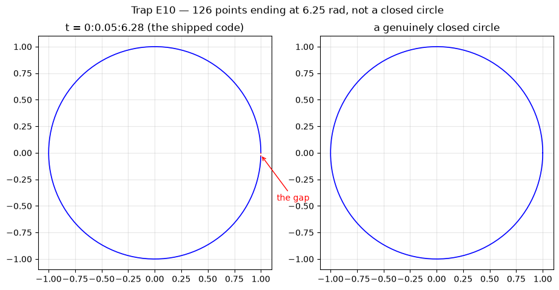

```python
# --- E10: the "circle" that is not closed -------------------------------------------------------------------
print(f"t = 0:0.05:6.28  ->  {CIRCLE_ANGLES.size} angles, first {CIRCLE_ANGLES[0]:g}, "
      f"last {CIRCLE_ANGLES[-1]:g} rad   (2*pi = {2 * np.pi:.6f})")
print(f"  the gap between the last sample and the first is {2 * np.pi - CIRCLE_ANGLES[-1]:.4f} rad = "
      f"{100 * (2 * np.pi - CIRCLE_ANGLES[-1]) / (2 * np.pi):.2f} % of the circumference: every modelled brash "
      "piece is an OPEN 125-gon")
arange = np.arange(0, 6.28, 0.05)
print(f"  `np.arange(0, 6.28, 0.05)` happens to land on the same {arange.size} values here (max difference "
      f"{np.abs(arange - CIRCLE_ANGLES).max():.1e}) — but it is NOT the same rule: MATLAB's colon "
      "fixes the element COUNT as fix((stop-start)/step)+1 and rebuilds the values, while np.arange accumulates "
      "and excludes the stop. Where the stop IS reached the two disagree outright:")
print(f"    matlab_colon(0, 0.1, 1) -> {matlab_colon(0.0, 0.1, 1.0).size} values ending "
      f"{matlab_colon(0.0, 0.1, 1.0)[-1]:g};   np.arange(0, 1, 0.1) -> {np.arange(0, 1, 0.1).size} values "
      f"ending {np.arange(0, 1, 0.1)[-1]:g}")
print("  core.matlab_compat.matlab_colon implements MATLAB's rule: it agrees with MATLAB on the length and the "
      "last value exactly, and to <= 1 ulp on 30 of these 126 angles (which changes the brash raster by 0 px)")

fig, axes = plt.subplots(1, 2, figsize=(11, 5))
for ax, ang, ttl in ((axes[0], CIRCLE_ANGLES, "t = 0:0.05:6.28 (the shipped code)"),
                     (axes[1], np.linspace(0, 2 * np.pi, 126), "a genuinely closed circle")):
    ax.plot(np.cos(ang), np.sin(ang), "b-", linewidth=1.2)
    ax.plot([np.cos(ang[-1]), np.cos(ang[0])], [np.sin(ang[-1]), np.sin(ang[0])], "r:", linewidth=1.2)
    ax.set_aspect("equal"); ax.set_title(ttl); ax.grid(alpha=0.3)
axes[0].annotate("the gap", xy=(1.0, -0.02), xytext=(1.15, -0.45),
                 arrowprops=dict(arrowstyle="->", color="r"), color="r")
fig.suptitle("Trap E10 — 126 points ending at 6.25 rad, not a closed circle")
plt.show()
```

```python
# --- D4: `c(1), c(2)` is a COLUMN-MAJOR read -----------------------------------------------------------------
centre_1x2 = np.array([[100.0, 300.0]])                      # the normal case: one connected component
centre_2x2 = np.array([[100.0, 300.0], [200.0, 400.0]])      # cat(1, cen.Centroid) when the label split in two
print(f"Center = {centre_1x2.tolist()}  ->  c(1), c(2) = {_matlab_c1c2(centre_1x2)}   (= x, y, as intended)")
print(f"Center = {centre_2x2.tolist()}  ->  c(1), c(2) = {_matlab_c1c2(centre_2x2)}   (= x1, x2 — NOT x1, y1)")
print("MATLAB stores matrices column by column, so element 2 of a 2x2 is the SECOND ROW of the FIRST COLUMN. "
      "4 of the 3452 shipped brash pieces have such a Center, and the shipped Circle sub-structures prove that "
      "MATLAB read them this way — so the port does too (deviation D4). Functionally inert here: every later "
      "USE of the field re-reads c(1), c(2) the same way.")

# --- R17: MATLAB grows `rgbImage` instead of pre-allocating it ------------------------------------------------
sub = ICE.Floe[:50]
sub_mcd = R.raw_mcd[:50]
grown = plot_color_bar_and_floe(COLOR_LIMIT_N, sub_mcd, ICE.Param.NumPix_y, len(sub), sub, LENGTH_OVER_PIXEL)
fixed = plot_color_bar_and_floe(COLOR_LIMIT_N, sub_mcd, ICE.Param.NumPix_y, len(sub), sub, LENGTH_OVER_PIXEL,
                                image_shape=(ICE.Param.NumPix_y, ICE.Param.NumPix_x))
print(f"\nthe image is {ICE.Param.NumPix_y} x {ICE.Param.NumPix_x} px")
print(f"  painting only the first {len(sub)} floes: MATLAB's grown rgbImage is "
      f"{grown.rgb_image.shape} — (max y, max x) over the PAINTED pixels")
print(f"  pre-allocating it instead would give {fixed.rgb_image.shape}")
print(f"  the painted content is identical where both exist: "
      f"{np.array_equal(grown.rgb_image, fixed.rgb_image[:grown.rgb_image.shape[0], :grown.rgb_image.shape[1]])}")
print("On the book's own section 8.3 field both maxima happen to be attained (the grown array is 627 x 1114 = "
      "the image size), so a full run there cannot tell 'grown' from 'pre-allocated' — which is why the "
      "verification used two deliberately smaller subsets instead, for which MATLAB returned 627x1096x3 and "
      "489x865x3. Both were reproduced byte for byte, 0 differing bytes of 2 061 576 and 1 268 955.")
```

```
Center = [[100.0, 300.0]]  ->  c(1), c(2) = (100.0, 300.0)   (= x, y, as intended)
Center = [[100.0, 300.0], [200.0, 400.0]]  ->  c(1), c(2) = (100.0, 200.0)   (= x1, x2 — NOT x1, y1)
MATLAB stores matrices column by column, so element 2 of a 2x2 is the SECOND ROW of the FIRST COLUMN. 4 of the 3452 shipped brash pieces have such a Center, and the shipped Circle sub-structures prove that MATLAB read them this way — so the port does too (deviation D4). Functionally inert here: ever…

the image is 1038 x 394 px
  painting only the first 50 floes: MATLAB's grown rgbImage is (596, 394, 3) — (max y, max x) over the PAINTED pixels
  pre-allocating it instead would give (1038, 394, 3)
  the painted content is identical where both exist: True
On the book's own section 8.3 field both maxima happen to be attained (the grown array is 627 x 1114 = the image size), so a full run there cannot tell 'grown' from 'pre-allocated' — which is why the verification used two deliberately smaller subsets instead, for which MATLAB returned 627x1096x3 and…
```

```
the small floe's hull lies entirely inside the big one's.
  the shipped test (`if xx ~= NaN` = `if ~isempty(xx)`): floe 1 overlaps [], floe 2 overlaps [] -> NOTHING is reported
  with strict_containment=True                        : floe 1 overlaps [2], floe 2 overlaps [1]
The boundaries do not CROSS, so polyxpoly returns empty and the published algorithm sees no overlap. That is a genuine limitation of the method as published, not a coding slip in the port; the opt-in flag exists so the difference can be measured, and the default reproduces the book.
```

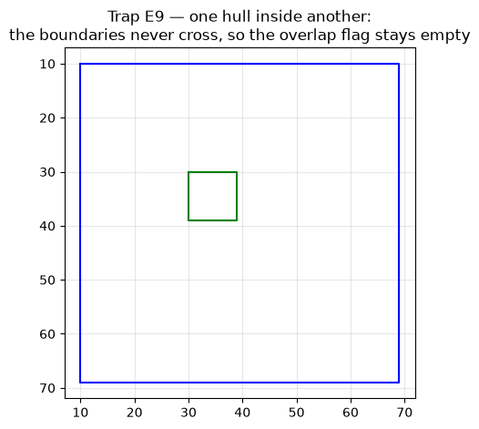

```python
# --- E9: `if xx ~= NaN` never sees containment ----------------------------------------------------------------
def square_pixels(x0, y0, w, h):
    """1-based [x, y] of every pixel of an axis-aligned block, in MATLAB `find` (column-major) order."""
    xs, ys = np.meshgrid(np.arange(x0, x0 + w), np.arange(y0, y0 + h))
    return np.column_stack([xs.ravel(order="F"), ys.ravel(order="F")]).astype(float)

big = square_pixels(10, 10, 60, 60)
small = square_pixels(30, 30, 10, 10)                      # strictly INSIDE the convex hull of `big`
nested = [IcePiece(Center=np.array([39.5, 39.5]), Area=big.shape[0], Perimeter=236.0, PixelsPosition=big),
          IcePiece(Center=np.array([34.5, 34.5]), Area=small.shape[0], Perimeter=36.0, PixelsPosition=small)]
blank = np.zeros((90, 90))

literal = sea_ice_model(nested, [], blank)                              # what the shipped code does
strict = sea_ice_model(nested, [], blank, strict_containment=True)      # the geometrically correct answer
print(f"the small floe's hull lies entirely inside the big one's.")
print(f"  the shipped test (`if xx ~= NaN` = `if ~isempty(xx)`): floe 1 overlaps "
      f"{literal.floe[0].Intersect.floe.tolist()}, floe 2 overlaps {literal.floe[1].Intersect.floe.tolist()} "
      "-> NOTHING is reported")
print(f"  with strict_containment=True                        : floe 1 overlaps "
      f"{strict.floe[0].Intersect.floe.tolist()}, floe 2 overlaps {strict.floe[1].Intersect.floe.tolist()}")
print("The boundaries do not CROSS, so polyxpoly returns empty and the published algorithm sees no overlap. "
      "That is a genuine limitation of the method as published, not a coding slip in the port; the opt-in flag "
      "exists so the difference can be measured, and the default reproduces the book.")

fig, ax = plt.subplots(figsize=(5, 5))
for f, colr in zip(literal.floe, ("b", "g")):
    ax.plot(f.Vertices[:, 0], f.Vertices[:, 1], colr + "-", linewidth=1.5)
ax.set_aspect("equal"); ax.invert_yaxis(); ax.grid(alpha=0.3)
ax.set_title("Trap E9 — one hull inside another:\nthe boundaries never cross, so the overlap flag stays empty")
plt.show()
```

## Parameter play (optional)

`color_limit_N` is the only free parameter of §8.3's figures: it fixes both the number of colours (`jet(color_limit_N)`) and the MCD above which every floe shares the last colour — the `≥30 [m]` of the book's colour bar. Moving it does not change a single measured value, only what the map *shows*, which makes it a clean demonstration of where display ends and data begins. Re-running is cheap (a fraction of a second), so this cell is interactive. Requires `ipywidgets`; without it only the static preview runs.

```
color_limit_N = 30: 66 of 196 floes (33.7 %) share the last colour, i.e. the bar reads '>= 30 m'.  Raw_MCD is unchanged: max |delta| = 0.0
```

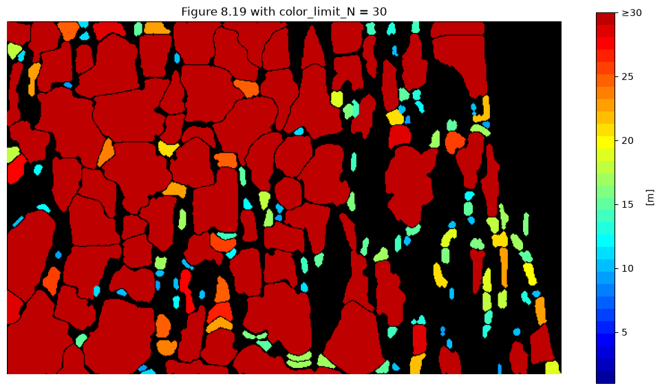

```python
def play(color_limit_n=30):
    r = mcd_analysis(ICE, length_over_pixel=LENGTH_OVER_PIXEL, color_limit_n=int(color_limit_n))
    clamped = int((r.raw.color_index > color_limit_n).sum())
    print(f"color_limit_N = {color_limit_n}: {clamped} of {r.raw.color_index.size} floes "
          f"({100 * clamped / r.raw.color_index.size:.1f} %) share the last colour, i.e. the bar reads "
          f"'>= {r.raw.centers[int(color_limit_n) - 1]:g} m'.  Raw_MCD is unchanged: max |delta| = "
          f"{np.abs(r.raw_mcd - R.raw_mcd).max():.1f}")
    img = r.raw.rgb_image if HAVE_BOOK_MAT else T(r.raw.rgb_image)
    fig, ax = plt.subplots(figsize=(13, 7))
    ax.imshow(img); ax.set_axis_off()
    mcd_colorbar(fig, ax, r.raw.color_m, (r.raw.centers[0], r.raw.centers[int(color_limit_n) - 1]))
    ax.set_title(f"Figure 8.19 with color_limit_N = {color_limit_n}")
    plt.show()

play()                                                    # the script's own setting
try:
    from ipywidgets import interact, IntSlider
    interact(play, color_limit_n=IntSlider(30, 5, 90, 5))
except ImportError:
    print("ipywidgets not installed - only the static preview above is shown")
```

## MATLAB ↔ Python mapping used in this chapter

| MATLAB | Python (`seaice`) | Parity | Note |
| --- | --- | --- | --- |
| `sqrt(A*4/pi)` (Eq. 8.1) | `core.stats.mean_caliper_diameter` | exact | reproduces the shipped `MCD_results.mat` at **0.0** on all 2888 values |
| `N_L(i) = size(find(MCD>=MCD(i)),2)/N_total` (Eq. 8.2) | `core.stats.cumulative_size_distribution` | exact | the M-file's literal `O(N²)` loop, ties repeated |
| `lsqcurvefit(F, p0, x, y)` | `core.fitting.lsqcurvefit` (SciPy `trf`) | near | MATLAB's own `optimoptions` defaults are transcribed; 5–10 s.f. agreement, `exitflag` identical in 4 of 4 |
| `jet(m)` | `core.plotting.matlab_jet` | exact | R2025a's `ceil(n/2) - (mod(m,4)==1)` rule; `jet(255)` matches bit for bit |
| `colormap/caxis/colorbar` of Figs. 8.19/8.20 | `core.plotting.mcd_colorbar` | display | the numbers behind it (`caxis = [1, 30]`) are exact |
| `hist(y, centres)` | `core.histogram.hist` | near/exact | bin **centres**, unbounded outer bins — `np.histogram` takes edges and would drop the tails |
| `start:step:stop` | `core.matlab_compat.matlab_colon` | near | MATLAB's element-count rule; `0:0.05:6.28` → 126 values ending 6.25 (≤ 1 ulp on 30 of them) |
| `convhull(x, y, 'simplify', true)` | `core.polygon.convhull` | near | the vertex **set** matches; MATLAB's start vertex and traversal direction are not reproducible |
| `polygeom(x, y)` | `core.polygon.polygeom` | exact | `Area` ≤ 1.8e-12 on all 2888 shipped floes |
| `roipoly`, `poly2mask` | `core.polygon.roipoly` | exact | 0 px against MATLAB's own raster |
| `polyxpoly(x1,y1,x2,y2)` | `core.polygon.polyxpoly` (and the faster `_segments_cross`) | exact | 4000/4000 randomised agreement, incl. collinear and touch cases |
| `struct` / `cat(1, …)` / `isfield`, and the whole Appendix-B layout | `core.icestruct` (+ `save_iceimage_mat` / `load_iceimage_mat`) | exact | every field of the shipped structure, incl. all 3992 overlap entries |
| `graythresh`/`im2bw`, `kmeans.m` | `core.threshold`, `core.clustering.kmeans_gray` | exact | inherited from ch03; §8.1's *results* remain `unverified` |
| the ch7 chain (`Algorithms 3/4/5`) | `ch07_ice_type.sea_ice_edge_detection` → `ice_shape_enhancement` | near/exact | verified in ch07; reused, not re-ported |

## Summary — what is verified, what is not, and what the next chapters need

**What Chapter 8 adds.** Nothing new in the way of image processing: it *uses* Chapters 2–7 and adds **measurement**. Five reusable primitives came out of it — `core.stats.mean_caliper_diameter` (Eq. 8.1), `core.stats.cumulative_size_distribution` (Eq. 8.2), `core.fitting` (`lsqcurvefit` + the three model functions), `core.icestruct` (the Appendix-B structure and its `.mat` I/O) and `core.matlab_compat.matlab_colon` — plus `core.plotting.matlab_jet` / `mcd_colorbar`.

**What is `exact`.** The whole §8.3 chain: `main_WL_new.m` → `plot_color_bar_and_floe.m` → Eq. (8.1) → Eq. (8.2) is **bit-exact** against MATLAB R2025a — every array at max |Δ| = **0.0**, including the 627 × 1114 × 3 painted map, byte for byte — and `Raw_MCD` also matches the authors' own shipped `MCD_results.mat` at 0.0. Re-running `sea_ice_model.m` on their 2888 floes and 3452 brash pieces reproduces their Appendix-B structure field by field, including all 3992 overlap-list entries as sets. `color_hist.m`, `color_hist_comparison.m` and `SeaIce_Image_Structure.m` are `exact` on every input tested.

**What is `near`, and why.** The power-law fits: SciPy's `trf` is the same Coleman–Li family as MATLAB's trust-region-reflective algorithm but not the same code, so α agrees to 10 significant figures rather than exactly (1.3703585384 vs 1.3703585381 — both print as **1.3704**). `matlab_colon` is within **1 ulp** on 30 of the 126 non-integer angles, which changes the brash raster by **0 px**. `convhull`'s vertex *order* is not reproducible, so the contract is the vertex set plus the raster. The upper-truncated power law's third parameter is unidentifiable (D2), so Python and MATLAB stop at different points of the same flat valley.

**Errata confirmed in MATLAB** (full list in `reports/ch08_verification.md`): E1 the unrunnable `fitting_iceFloes_distribution.m`; E2 the text describing a log-log slope its code never computes; E3 Fig. 8.15's colour bar belonging to the *other* file; E4 the truncated 15.94 %; E5 "clipper" for caliper; E6 the "not smaller" claim that is false in both readings; E7 the `.mat` contradicting its own script; E8 the FSD's wrong labels and right counts; E9 `if xx ~= NaN`; E10 the open 125-gon; E11 Fig. 8.15's subtraction stated backwards.

**Feeds forward.** *Chapter 9 (model-ice applications)* works on tank ice — rectangular floes, concentration from video, maximum floe size monitoring — and will reuse `core.matlab_compat.matlab_colon`, `core.stats`, `core.icestruct` and the whole ch6/ch7 identification chain, on synthetic and model-basin data rather than aerial photographs. *Chapter 10 (Appendix A, geometric calibration)* owns the rectifier this chapter deliberately did **not** write: the analytic orthorectification of A.1.1 and the linear four-corner method of A.1.2 that §8.1's shipborne frames and §7.3.1.2's oblique images both need. When it lands, §8.1's procedure becomes runnable end to end on any oblique frame a reader supplies.

The learned knowledge for this chapter is in `knowledge/ch08.md` and `knowledge/CUMULATIVE.md`; the evidence is in `reports/ch08_verification.md`.